# PREZENTACJA

## Analiza zbioru IRIS

**Eksploracyjna analiza danych – kwiaty irysa**

[Andrzej Wolski]  
[Marzec 2026]

[figure not shown]

## Czym jest zbiór Iris?

- 150 próbek (50 z każdego gatunku)
- 3 gatunki:
  - **Setosa**
  - **Versicolor**
  - **Virginica**
- 4 cechy mierzone:
  - długość i szerokość działki kielicha
  - długość i szerokość płatka

## Cel opracowania

- Poznać strukturę i charakterystyki danych
- Sprawdzić zależności między cechami
- Zobaczyć, jak bardzo gatunki różnią się od siebie
- Przygotować dane do ewentualnego modelu klasyfikacji

## Krótka charakterystyka danych

- 150 wierszy, 5 kolumn
- Brak brakujących wartości
- Wszystkie cechy liczbowe (cm)
- Zmienna docelowa: `species` (3 klasy)

**Średnie wartości:**

- Długość płatka: 3,76 cm
- Szerokość płatka: 1,20 cm

## Zależności między cechami

- Najsilniejsza korelacja: długość płatka ↔ szerokość płatka
- Setosa wyraźnie oddzielona od pozostałych gatunków
- Versicolor i Virginica częściowo nakładają się

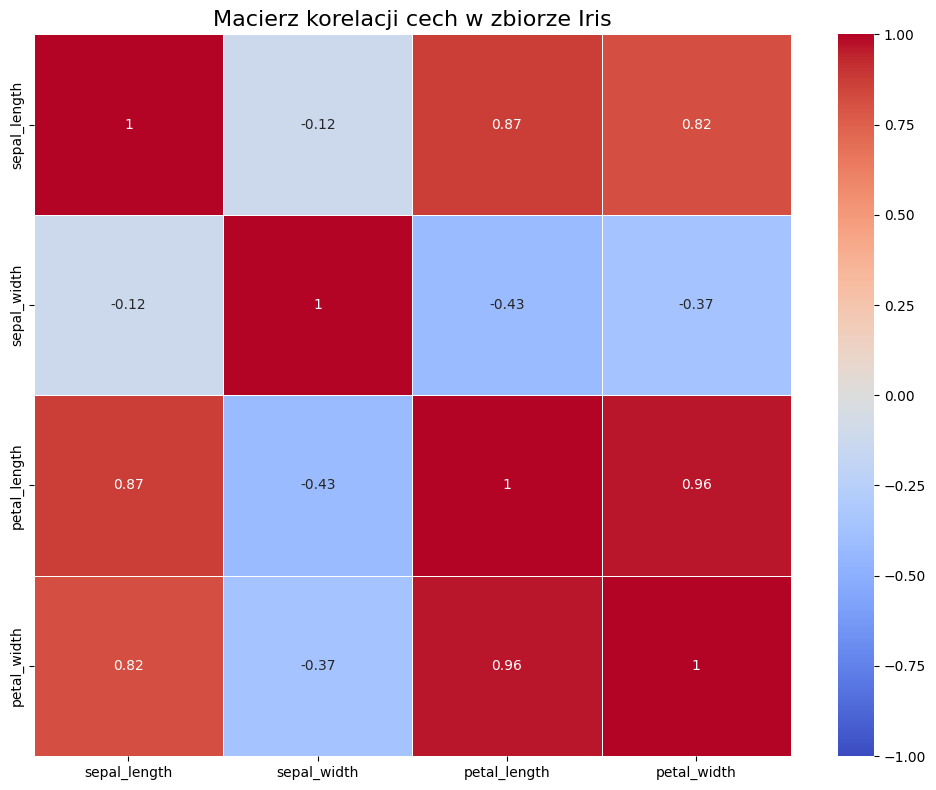

```python
import seaborn as sns
import matplotlib.pyplot as plt

# Ładujemy zbiór Iris (nie musimy mieć pliku CSV)
df = sns.load_dataset("iris")

# Obliczenie macierzy korelacji
corr = df.corr(numeric_only=True)

# Duży, ładny wykres
plt.figure(figsize=(10, 8))
sns.heatmap(corr,
            annot=True,
            cmap='coolwarm',
            vmin=-1, vmax=1,
            linewidths=0.5)

plt.title('Macierz korelacji cech w zbiorze Iris', fontsize=16)
plt.tight_layout()
plt.show()
```

## Szczegółowa interpretacja korelacji

- Petal length i petal width: korelacja > 0,96
- Sepal length i petal length: korelacja ok. 0,87
- Słaba korelacja z szerokością działki kielicha

→ Im dłuższy i szerszy płatek, tym łatwiej odróżnić gatunek

## Rozkład cech w gatunkach

- Setosa ma wyraźnie najmniejsze płatki
- Virginica ma największe płatki
- Versicolor – wartości pośrednie

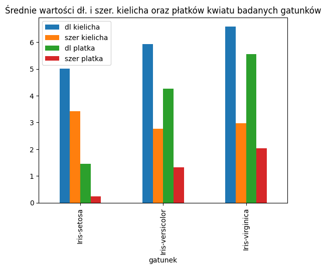

```python
df.groupby('gatunek').mean().plot(kind='bar',title='Średnie wartości dł. i szer. kielicha oraz płatków kwiatu badanych gatunków')
```

# WNIOSKI

## Dziękuję za uwagę!

Pytania?

[Andrzej Wolski]  
[Voland 1810]